| [SOCR ≫](http://www.socr.umich.edu) | [DSPA ≫](http://Predictive.Space) | [Topics ≫](http://DSPA.predictive.space/) |
| --- | --- | --- |

# Data Science and Predictive Analytics (UMich HS650)

May 2019

As we learned in [Chapters 6-8](http://dspa.predictive.space), classification could help us make predictions on new observations. However, classification requires (human supervised) predefined label classes. What if we are in the early phases of a study and/or don’t have the required resources to manually define, derive or generate these class labels?

*Clustering* can help us explore the dataset and separate cases into groups representing similar traits or characteristics. Each group could be a potential candidate for a class. Clustering is used for exploratory data analytics, i.e., as *unsupervised learning*, rather than for confirmatory analytics or for predicting specific outcomes.

In this chapter, we will present (1) clustering as a machine learning task, (2) the *silhouette* plots for assessing the reliability of clustering, (3) the *k-Means* clustering algorithm and how to tune it, (4) examples of several interesting case-studies, including Divorce and Consequences on Young Adults, Pediatric Trauma, and Youth Development, (5) demonstrate hierarchical clustering, (6) show spectral clustering, and (7) present Gaussian mixture modeling.

# 1 Clustering as a machine learning task

As we mentioned earlier, clustering is a machine learning technique that bundles unlabeled cases into groups. Scatter plots we saw in previous chapters represent a simple illustration of the clustering process. Let’s start with a [hotdogs example](http://wiki.socr.umich.edu/index.php/SOCR_012708_ID_Data_HotDogs). Assume we don’t know much about the ingredients of frankfurter hot dogs and we look the following graph.

[output not shown]

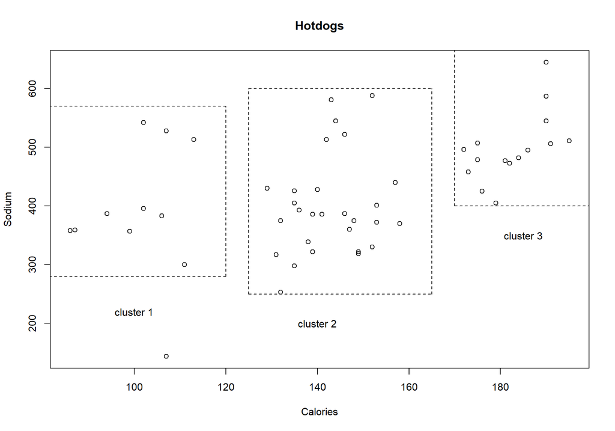

In terms of calories and sodium, these hot dogs are clearly separated into three different clusters. *Cluster 1* has hot dogs of low calories and medium sodium content; *Cluster 2* has both calorie and sodium at medium levels; *Cluster 3* has both sodium and calories at high levels. We can make a bold guess about the ingredients used in the hot dogs in these three clusters. For cluster 1, it could be mostly *chicken* meat since it has low calories. The second cluster might be *beef* and the third one is likely to be *pork*, because beef hot dogs have considerably less calories and salt than pork hot dogs. However, this is just guessing. Some hot dogs have a mixture of two or three types of meat. The real situation is somewhat similar to what we guessed but with some random noise, especially in cluster 2.

The following pair of plots show the primary type of meat used for each hot dog labeled by name (top) and color-coded (bottom).

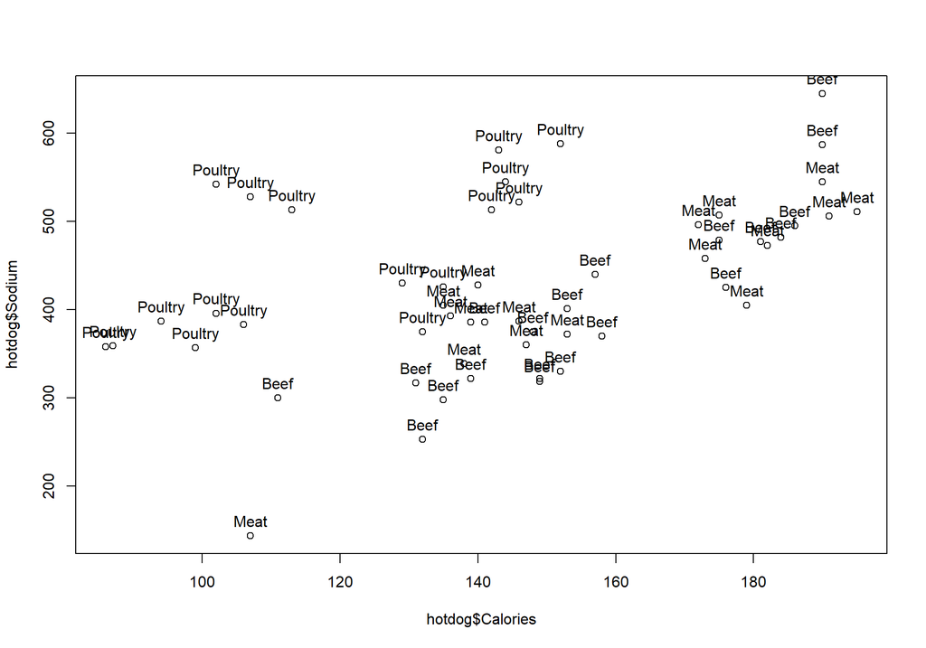

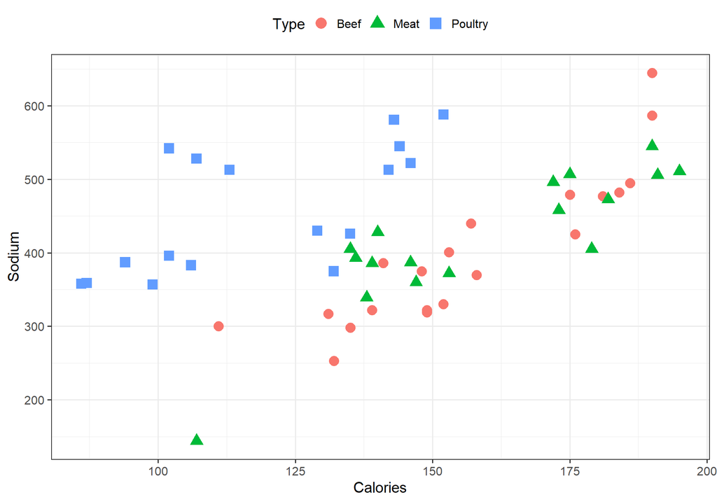

# 2 Silhouette plots

Silhouette plots are useful for interpretation and validation of consistency of all clustering algorithms. The silhouette value, $sil \in [-1,1]$, measures the similarity (cohesion) of a data point to its cluster relative to other clusters (separation). Silhouette plots rely on a distance metric, e.g., the [Euclidean distance](https://en.wikipedia.org/wiki/Euclidean_distance), [Manhattan distance](https://en.wikipedia.org/wiki/Manhattan_distance), [Minkowski distance](https://en.wikipedia.org/wiki/Minkowski_distance), etc.

- A high silhouette value suggest that the data matches its own cluster well.
- A clustering algorithm performs well when most Silhouette values are high.
- A low silhouette value indicates poor matching within neighboring cluster.
- Poor clustering may imply that the algorithm configuration may have too many or too few clusters.

Suppose a clustering method groups all data points (objects), $\{X_i\}_i$, into $k$ clusters and define:

- $d_i$ as the *average dissimilarity* of $X_i$ with all other data points within its cluster. $d_i$ captures the quality of the assignment of $X_i$ to its current class label. Smaller or larger $d_i$ values suggest better or worse overall assignment for $X_i$ to its cluster, respectively. The average dissimilarity of $X_i$ to a cluster $C$ is the average distance between $X_i$ and all points in the cluster of points labeled $C$.
- $l_i$ as the *lowest average dissimilarity* of $X_i$ to any other cluster, that $X_i$ is not a member of. The cluster corresponding to $l_i$, the lowest average dissimilarity, is called the $X_i$ **neighboring cluster**, as it is the next best fit cluster for $X_i$.

Then, the **silhouette** of $X_i$ is defined by:

$$-1 \leq s_i = \frac{l_i - d_i}{\max\{l_i, d_i\}}
\equiv \begin{cases}
1-\frac{d_i}{l_i}, & \mbox{if } d_i < l_i \\
0, & \mbox{if } d_i = l_i \\
\frac{l_i}{d_i}-1, & \mbox{if } d_i > l_i \\
\end{cases} \leq 1$$

Note that:

- $-1\leq s_i \leq 1$,
- $s_i \longrightarrow 1$ when $d_i \ll l_i$, i.e., the dissimilarity of $X_i$ to its cluster $C$ is much lower relative to its dissimilarity to other clusters, indicating a good (cluster assignment) match. Thus, high Silhouette values imply the data is appropriately clustered.
- Conversely, $-1 \longleftarrow s_i$ when $l_i \ll d_i$, $d_i$ is large, implying a poor match of $X_i$ with its current cluster $C$, relative to neighboring clusters. $X_i$ may be more appropriately clustered in its neighboring cluster.
- $s_i \sim 0$ means that the $X_i$ may lie on the border between two natural clusters.

# 3 The k-Means Clustering Algorithm

The *K-means* algorithm is one of the most commonly used algorithms for clustering.

## 3.1 Using distance to assign and update clusters

This algorithm is similar to *k-nearest neighbors (KNN)* presented in [Chapter 6](http://www.socr.umich.edu/people/dinov/courses/DSPA_notes/06_LazyLearning_kNN.html). In clustering, we don’t have a priori pre-determined labels, and the algorithm is trying to deduce intrinsic groupings in the data.

Similar to KNN, k-means uses Euclidean distance ($|. |_2$ norm) most of the times, however Manhattan distance ($|. |_1$ norm), or the more general Minkowski distance ($(\sum_{i=1}^n{|p_i - q_i|^c})^{\frac{1}{c}}$) may also be used. For $c=2$, the Minkowski distance represents the classical Euclidean distance:
$$dist(x, y)=\sqrt{\sum_{n=1}^n(x_i-y_i)^2}.$$

How can we separate clusters using this formula? The **k-means protocol** is as follows:

- *Initiation*: First, we define *k* points as cluster centers. Often these points are *k* random points from the dataset. For example if *k=3* we choose 3 random points in the dataset as cluster centers.
- *Assignment*: Second, we determine the maximum extent of the cluster boundaries that all have maximal distance from their cluster centers. Now the data is separated into *k* initial clusters. The assignment of each observation to a cluster is based on computing the least within-cluster sum of squares according to the chosen distance. Mathematically, this is equivalent to [Voronoi tessellation](https://en.wikipedia.org/wiki/Centroidal_Voronoi_tessellation) of the space of the observations according to their mean distances.
- *Update*: We update the centers of our clusters to the new *means* of the cluster centroid locations. This updating phase is the essence of the *k-means* algorithm.

Although there is no guarantee that the *k-means* algorithm converges to a global optimum, in practice, the algorithm tends to converge, i.e., the assignments no longer change, to a local minimum as there are only a finite number of such Voronoi partitionings, see the [SOCR 2D Interactive Voronoi Tessellation App](http://socr.umich.edu/HTML5/others/Voronoi_App/).

## 3.2 Choosing the appropriate number of clusters

We don’t want our number of clusters to be either too large or too small. If it is too large, the groups are too specific to be meaningful. On the other hand, too few groups might be too broadly general to be useful. As we mentioned in [Chapter 6](http://www.socr.umich.edu/people/dinov/courses/DSPA_notes/06_LazyLearning_kNN.html), $k=\sqrt{\frac{n}{2}}$ is a good place to start. However, it might generate a large number of groups.

Also, the elbow method may be used to determine the relationship of $k$ and homogeneity of the observations within each cluster.

When we graph within-group homogeneity against $k$, we can find an “elbow point” that suggests a minimum $k$ corresponding to relatively large within-group homogeneity.

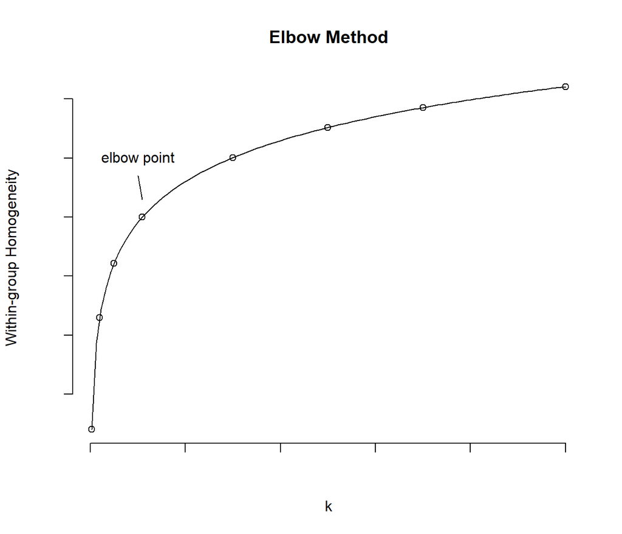

This graph shows that homogeneity barely increases above the “elbow point”. There are various ways to measure homogeneity within a cluster. Further detailed about these choices are provided in this paper [On clustering validation techniques, Journal of Intelligent Information Systems Vol. 17, pp. 107-145, by M. Halkidi, Y. Batistakis, and M. Vazirgiannis (2001)](http://dx.doi.org/10.1023/A:1012801612483).

# 4 Case Study 1: Divorce and Consequences on Young Adults

## 4.1 Step 1 - collecting data

The dataset we will be using is the [Divorce and Consequences on Young Adults dataset](https://umich.instructure.com/files/399121/download?download_frd=1). This is a longitudinal study focused on examining the consequences of recent parental divorce for young adults (initially ages 18-23) whose parents had divorced within 15 months of the study’s first wave (1990-91). The sample consisted of 257 White respondents with newly divorced parents. Here we have a subset of this dataset with 47 respondents in [our case-studies folder, CaseStudy01_Divorce_YoungAdults_Data.csv](https://umich.instructure.com/courses/38100/files/folder/Case_Studies).

### 4.1.1 Variables

- **DIVYEAR**: Year in which parents were divorced. Dichotomous variable with 1989 and 1990
- **Child affective relations**:
  - Momint: Mother intimacy. Interval level data with 4 possible responses (1-extremely close, 2-quite close, 3-fairly close, 4- not close at all)
  - Dadint: Father intimacy. Interval level data with 4 possible responses (1-extremely close, 2-quite close, 3-fairly close, 4-not close at all)
  - Live with mom: Polytomous variable with 3 categories (1- mother only, 2- father only, 3- both parents)
- **momclose**: measure of how close the child is to the mother (1-extremely close, 2-quite close, 3-fairly close, 4- not close at all).
- **Depression**: Interval level data regarding feelings of depression in the past 4 weeks. Possible responses are 1-often, 2-sometimes, 3-hardly ever, 4-never
- **Gethitched**: Polytomous variable with 4 possible categories indicating respondent’s plan for marriage (1-Marry fairly soon, 2-marry sometime, 3-never marry, 8-don’t know)

## 4.2 Step 2 - exploring and preparing the data

Let’s load the dataset and pull out a summary of all variables.

```r
divorce<-read.csv("https://umich.instructure.com/files/399118/download?download_frd=1")
summary(divorce)
```

```
##     DIVYEAR          momint          dadint         momclose
##  Min.   :89.00   Min.   :1.000   Min.   :1.000   Min.   :1.000
##  1st Qu.:89.00   1st Qu.:1.000   1st Qu.:2.000   1st Qu.:1.000
##  Median :90.00   Median :1.000   Median :2.000   Median :2.000
##  Mean   :89.68   Mean   :1.809   Mean   :2.489   Mean   :1.809
##  3rd Qu.:90.00   3rd Qu.:3.000   3rd Qu.:3.000   3rd Qu.:2.000
##  Max.   :90.00   Max.   :4.000   Max.   :4.000   Max.   :4.000
##    depression     livewithmom      gethitched
##  Min.   :1.000   Min.   :1.000   Min.   :1.000
##  1st Qu.:2.000   1st Qu.:1.000   1st Qu.:2.000
##  Median :3.000   Median :1.000   Median :2.000
##  Mean   :2.851   Mean   :1.489   Mean   :2.213
##  3rd Qu.:4.000   3rd Qu.:2.000   3rd Qu.:2.000
##  Max.   :4.000   Max.   :9.000   Max.   :8.000
```

According to the summary, DIVYEAR is actually a dummy variable (either 89 or 90). We can re-code (binarize) the DIVYEAR using the `ifelse()` function (mentioned in [Chapter 7](http://www.socr.umich.edu/people/dinov/courses/DSPA_notes/07_NaiveBayesianClass.html)). The following line of code generates a new indicator variable for *divorce year=1990*.

```r
divorce$DIVYEAR<-ifelse(divorce$DIVYEAR==89, 0, 1)
```

We also need another preprocessing step to deal with `livewithmom`, which has missing values, `livewithmom=9`. We can impute these using `momint` and `dadint` variables for each specific participant

```r
table(divorce$livewithmom)
```

```
##
##  1  2  9
## 31 15  1
```

```r
divorce[divorce$livewithmom==9, ]
```

```
##    DIVYEAR momint dadint momclose depression livewithmom gethitched
## 45       1      3      1        3          3           9          2
```

For instance, respondents that feel much closer to their dads may be assigned `divorce$livewithmom==2`, suggesting they most likely live with their fathers. Of course, alternative imputation strategies are also possible.

```r
divorce[45, 6]<-2
divorce[45, ]
```

```
##    DIVYEAR momint dadint momclose depression livewithmom gethitched
## 45       1      3      1        3          3           2          2
```

## 4.3 Step 3 - training a model on the data

We are only using R base functionality, so no need to install any additional packages now, `library(stats)` may be necessary. Then, the function `kmeans()` will provide the *k-means* clustering of the data.

`myclusters<-kmeans(mydata, k)`

- *mydata*: dataset in a matrix form.
- *k*: number of clusters we want to create.

The *output* consists of:

- *myclusters$cluster*: vector indicating the cluster number for every observation.
- *myclusters$center*: a matrix showing the mean feature values for every center.
- *mycluster$size*: a table showing how many observations are assigned to each cluster.

Before we perform clustering, we need to standardize the features to avoid biasing the clustering based on features that use large-scale values. Note that distance calculations are sensitive to measuring units. `as.data.frame()` will convert our dataset into a data frame allowing us to use the `lapply()` function. Next, we use a combination of `lapply()` and `scale()` to standardize our data.

```r
di_z<- as.data.frame(lapply(divorce, scale))
str(di_z)
```

```
## 'data.frame':    47 obs. of  7 variables:
##  $ DIVYEAR    : num  0.677 0.677 -1.445 0.677 -1.445 ...
##  $ momint     : num  1.258 1.258 -0.854 1.258 -0.854 ...
##  $ dadint     : num  -0.514 -0.514 0.536 1.586 0.536 ...
##  $ momclose   : num  0.225 1.401 -0.951 1.401 0.225 ...
##  $ depression : num  0.164 -0.937 1.265 0.164 -2.038 ...
##  $ livewithmom: num  -0.711 1.377 -0.711 -0.711 -0.711 ...
##  $ gethitched : num  0.846 -0.229 -0.229 0.846 -0.229 ...
```

The resulting dataset, `di_z`, is standardized so all features are unitless and follow approximately standardized normal distribution.

Next, we need to think about selecting a proper $k$. We have a relatively small dataset with 47 observations. Obviously we cannot have a $k$ as large as 10. The rule of thumb suggests $k=\sqrt{47/2}=4.8$. This would be relatively large also because we will have less than 10 observations for each cluster. It is very likely that for some clusters we only have one observation. A better choice may be 3. Let’s see if this will work.

```r
library(stats)
set.seed(321)
diz_clussters<-kmeans(di_z, 3)
```

## 4.4 Step 4 - evaluating model performance

Let’s look at the clusters created by the *k-means* model.

```r
diz_clussters$size
```

```
## [1] 12 24 11
```

At first glance, it seems that 3 worked well for the number of clusters. We don’t have any cluster that contains a small number of observations. The three clusters have relatively equal number of respondents.

*Silhouette* plots represent the most appropriate evaluation strategy to assess the quality of the clustering. Silhouette values are between -1 and 1. In our case, two data points correspond to a negative Silhouette values, suggesting these cases may be “mis-clustered”, or perhaps are ambiguous as the Silhouette value is close to 0. We can observe that the average Silhouette is reasonable, about $0.2$.

```r
require(cluster)
dis = dist(di_z)
sil = silhouette(diz_clussters$cluster, dis)
summary(sil)
```

```
## Silhouette of 47 units in 3 clusters from silhouette.default(x = diz_clussters$cluster, dist = dis) :
##  Cluster sizes and average silhouette widths:
##         12         24         11
## 0.16444649 0.27684356 0.07921684
## Individual silhouette widths:
##     Min.  1st Qu.   Median     Mean  3rd Qu.     Max.
## -0.08466  0.11765  0.20077  0.20189  0.30448  0.39825
```

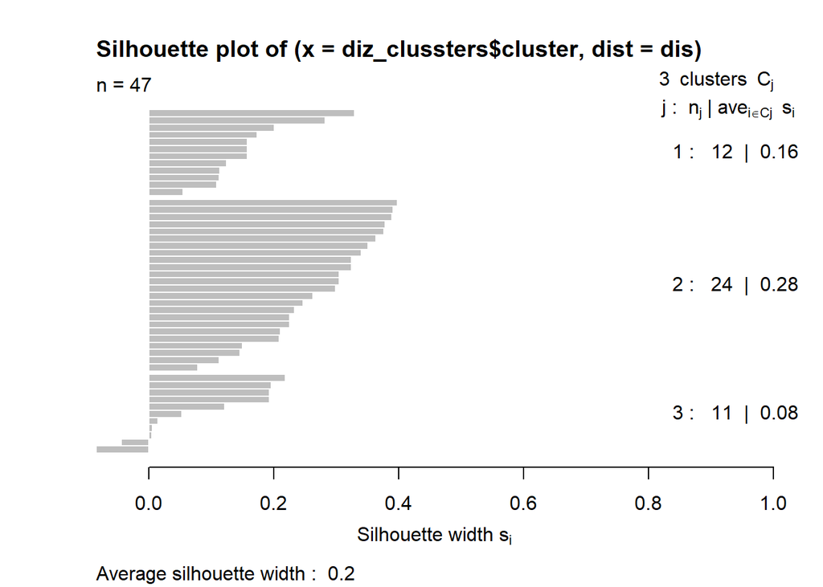

```r
plot(sil)
```

The next step would be to interpret the clusters in the context of this social study.

```r
diz_clussters$centers
```

```
##      DIVYEAR     momint      dadint   momclose depression livewithmom
## 1  0.5004720  1.1698438 -0.07631029  1.2049200 -0.1112567   0.1591755
## 2 -0.2953914 -0.5016290  0.36107795 -0.5096937  0.1180883  -0.7107373
## 3  0.0985208 -0.1817299 -0.70455885 -0.2023993 -0.1362761   1.3770536
##   gethitched
## 1 -0.1390230
## 2 -0.1390230
## 3  0.4549845
```

We can see that these three different clusters do contain three alternative types of young adults.

Bar plots provide an alternative strategy to visualize the difference between clusters.

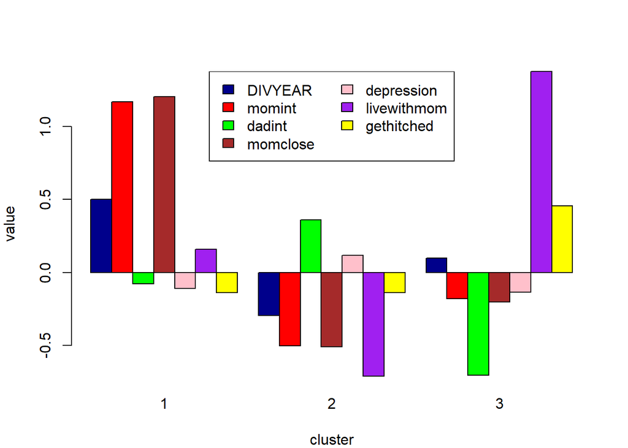

```r
par(mfrow=c(1, 1), mar=c(4, 4, 4, 2))
myColors <- c("darkblue", "red", "green", "brown", "pink", "purple", "yellow")
barplot(t(diz_clussters$centers), beside = TRUE, xlab="cluster",
ylab="value", col = myColors)
legend("top", ncol=2, legend = c("DIVYEAR", "momint", "dadint", "momclose", "depression", "livewithmom", "gethitched"), fill = myColors)
```

For each of the three clusters, the bars in the plot above represent the following order of features `DIVYEAR, momint, dadint, momclose, depression, livewithmom, gethitched`.

## 4.5 Step 5 - usage of cluster information

Clustering results could be utilized as new information augmenting the original dataset. For instance, we can add a *cluster* label in our `divorce` dataset:

```r
divorce$clusters<-diz_clussters$cluster
divorce[1:5, ]
```

```
##   DIVYEAR momint dadint momclose depression livewithmom gethitched
## 1       1      3      2        2          3           1          3
## 2       1      3      2        3          2           2          2
## 3       0      1      3        1          4           1          2
## 4       1      3      4        3          3           1          3
## 5       0      1      3        2          1           1          2
##   clusters
## 1        1
## 2        1
## 3        2
## 4        1
## 5        2
```

We can also examine the relationship between live with mom and feel close to mom by displaying a scatter plot of these two variables. If we suspect that young adults’ personality might affect this relationship, then we could consider the potential personality (cluster type) in the plot. The cluster labels associated with each participant are printed in different positions relative to each pair of observations, `(livewithmom, momint)`.

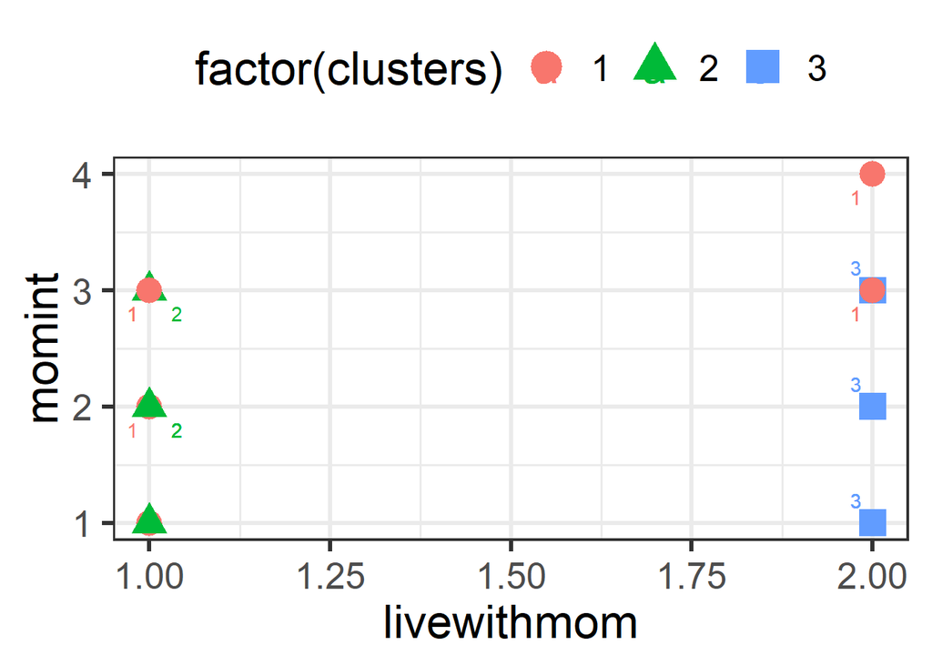

```r
require(ggplot2)
ggplot(divorce, aes(livewithmom, momint), main="Scatterplot Live with mom vs feel close to mom") +
  geom_point(aes(colour = factor(clusters), shape=factor(clusters), stroke = 8), alpha=1) +
  theme_bw(base_size=25) +
  geom_text(aes(label=ifelse(clusters%in%1, as.character(clusters), ''), hjust=2, vjust=2, colour = factor(clusters)))+
  geom_text(aes(label=ifelse(clusters%in%2, as.character(clusters), ''), hjust=-2, vjust=2, colour = factor(clusters)))+
  geom_text(aes(label=ifelse(clusters%in%3, as.character(clusters), ''), hjust=2, vjust=-1, colour = factor(clusters))) +
  guides(colour = guide_legend(override.aes = list(size=8))) +
theme(legend.position="top")
```

We used `ggplot()` function in `ggplot2` package to label points with cluster types. `ggplot(divorce, aes(livewithmom, momint))+geom_point()` gives us the scatterplot and the three `geom_text()` functions help us label the points with the corresponding cluster identifiers.

This picture shows that live with mom does not necessarily mean young adults will feel close to mom. For “emotional” (cluster 1) young adults, they felt close to their mom whether they live with their mom or not. “Naive” (cluster 2) young adults feel closer to mom if they live with mom. However, they tend to be estranged from their mother. “Independent” (cluster 3) young adults are opposite to cluster 1. They felt closer to mom if they don’t live with her.

# 5 Model improvement

Let’s still use the divorce data to illustrate a model improvement using **k-means++**.

(Appropriate) initialization of the **k-means** algorithm is of paramount importance. The **k-means++** extension provides a practical strategy to obtain an optimal initialization for k-means clustering using a predefined `kpp_init` method.

```r
# install.packages("matrixStats")
library(matrixStats)
```

```r
kpp_init = function(dat, K) {
  x = as.matrix(dat)
  n = nrow(x)
  # Randomly choose a first center
  centers = matrix(NA, nrow=K, ncol=ncol(x))
  set.seed(123)
  centers[1,] = as.matrix(x[sample(1:n, 1),])
  for (k in 2:K) {
    # Calculate dist^2 to closest center for each point
    dists = matrix(NA, nrow=n, ncol=k-1)
    for (j in 1:(k-1)) {
      temp = sweep(x, 2, centers[j,], '-')
      dists[,j] = rowSums(temp^2)
    }
    dists = rowMins(dists)
    # Draw next center with probability proportional to dist^2
    cumdists = cumsum(dists)
    prop = runif(1, min=0, max=cumdists[n])
    centers[k,] = as.matrix(x[min(which(cumdists > prop)),])
  }
  return(centers)
}

clust_kpp = kmeans(di_z, kpp_init(di_z, 3), iter.max=100, algorithm='Lloyd')
```

We can observe some differences.

```r
clust_kpp$centers
```

```
##      DIVYEAR     momint     dadint   momclose depression livewithmom
## 1  0.3741445  1.2578161 -0.6636602  0.5610651 -0.1505730  -0.4124815
## 2 -0.2659149 -0.5798266  0.3805174 -0.2538624  0.1639572  -0.5560862
## 3  0.3508225  0.5269697 -0.4329499  0.2251408 -0.2594488   1.3770536
##   gethitched
## 1  0.9990071
## 2 -0.1489684
## 3 -0.2285310
```

This improvement is not substantial - the new overall average Silhouette value remains $0.2$ for **k-means++**, compared with the value of $0.2$ reported for the earlier k-means clustering, albeit the 3 groups generated by each method are quite distinct. In addition, the number of “mis-clustered” instances remains 2 although their Silhouette values are rather smaller than before and the overall cluster 1 Silhouette average value is low ($0.006$).

```r
sil2 = silhouette(clust_kpp$cluster, dis)
summary(sil2)
```

```
## Silhouette of 47 units in 3 clusters from silhouette.default(x = clust_kpp$cluster, dist = dis) :
##  Cluster sizes and average silhouette widths:
##          7         27         13
## 0.00644352 0.24933847 0.19476785
## Individual silhouette widths:
##     Min.  1st Qu.   Median     Mean  3rd Qu.     Max.
## -0.12747  0.08781  0.22955  0.19807  0.29048  0.38115
```

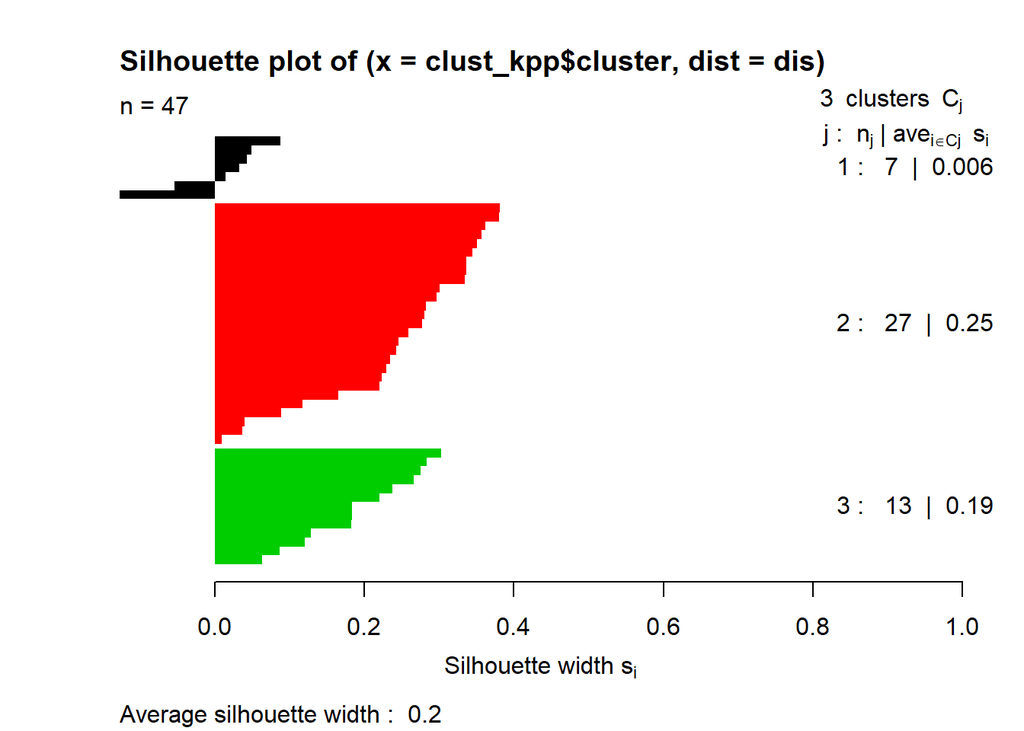

```r
plot(sil2, col=1:length(diz_clussters$size), border=NA)
```

## 5.1 Tuning the parameter $k$

Similar to what we performed for KNN and SVM, we can tune the **k-means** parameters, including centers initialization and $k$.

```r
n_rows <- 21
mat = matrix(0,nrow = n_rows)
for (i in 2:n_rows){
  set.seed(321)
  clust_kpp = kmeans(di_z, kpp_init(di_z, i), iter.max=100, algorithm='Lloyd')
  sil = silhouette(clust_kpp$cluster, dis)
  mat[i] = mean(as.matrix(sil)[,3])
}
colnames(mat) <- c("Avg_Silhouette_Value")
mat
```

```
##       Avg_Silhouette_Value
##  [1,]            0.0000000
##  [2,]            0.1948335
##  [3,]            0.1980686
##  [4,]            0.1789654
##  [5,]            0.1716270
##  [6,]            0.1546357
##  [7,]            0.1622488
##  [8,]            0.1767659
##  [9,]            0.1928883
## [10,]            0.2026559
## [11,]            0.2006313
## [12,]            0.1586044
## [13,]            0.1735035
## [14,]            0.1707446
## [15,]            0.1626367
## [16,]            0.1609723
## [17,]            0.1785733
## [18,]            0.1839546
## [19,]            0.1660019
## [20,]            0.1573574
## [21,]            0.1561791
```

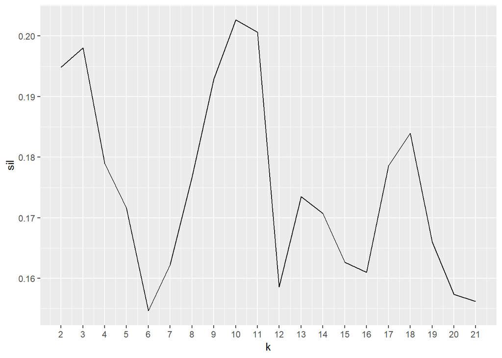

```r
ggplot(data.frame(k=2:n_rows,sil=mat[2:n_rows]),aes(x=k,y=sil))+
  geom_line()+
  scale_x_continuous(breaks = 2:n_rows)
```

This suggests that $k\sim 3$ may be an appropriate number of clusters to use in this case.

```r
k <- 3
set.seed(31)
clust_kpp = kmeans(di_z, kpp_init(di_z, k), iter.max=200, algorithm="MacQueen")
sil3 = silhouette(clust_kpp$cluster, dis)
summary(sil3)
```

```
## Silhouette of 47 units in 3 clusters from silhouette.default(x = clust_kpp$cluster, dist = dis) :
##  Cluster sizes and average silhouette widths:
##         10         22         15
## 0.02096194 0.30414984 0.15474729
## Individual silhouette widths:
##    Min. 1st Qu.  Median    Mean 3rd Qu.    Max.
## -0.1365  0.1032  0.1971  0.1962  0.3122  0.4113
```

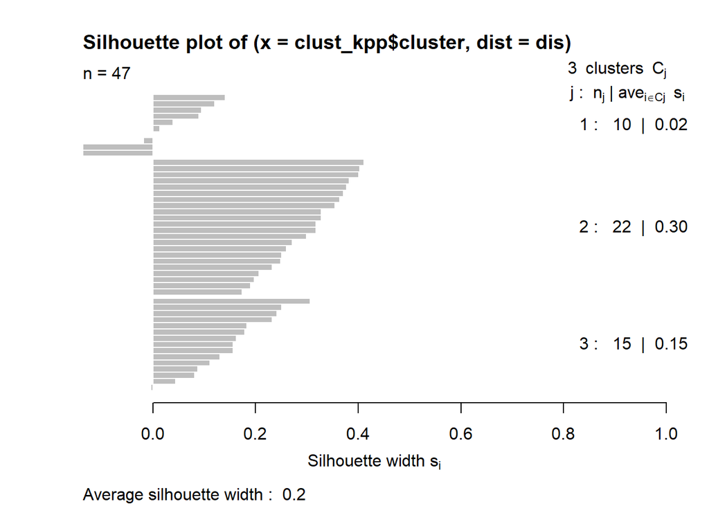

```r
plot(sil3)
```

Note that we now see 3 cases of group 1 that have negative silhouette values (previously we had only 2), albeit the overall average silhouette remains $0.2$.

# 6 Case study 2: Pediatric Trauma

Let’s go through another example demonstrating the *k-means* clustering method using a larger dataset.

## 6.1 Step 1 - collecting data

The dataset we will interrogate now includes [Services Utilization by Trauma-Exposed Children in the US data](https://umich.instructure.com/files/399127/download?download_frd=1), which is located in [our case-studies folder](https://umich.instructure.com/courses/38100/files/folder/Case_Studies). This case study examines associations between post-traumatic psychopathology and service utilization by trauma-exposed children.

**Variables**:

- **id**: Case identification number.
- **sex**: Female or male, dichotomous variable (1= female, 0= male).
- **age**: Age of child at time of seeking treatment services. Interval-level variable, score range= 0-18.
- **race**: Race of child seeking treatment services. Polytomous variable with 4 categories (1= black, 2= white, 3= hispanic, 4= other).
- **cmt**: The child was exposed to child maltreatment trauma - dichotomous variable (1= yes, 0= no).
- **traumatype**: Type of trauma exposure the child is seeking treatment sore. Polytomous variable with 5 categories (“sexabuse”= sexual abuse, “physabuse”= physical abuse, “neglect”= neglect, “psychabuse”= psychological or emotional abuse, “dvexp”= exposure to domestic violence or intimate partner violence).
- **ptsd**: The child has current post-traumatic stress disorder. Dichotomous variable (1= yes, 0= no).
- **dissoc**: The child has currently has a dissociative disorder (PTSD dissociative subtype, DESNOS, DDNOS). Interval-level variable, score range= 0-11.
- **service**: Number of services the child has utilized in the past 6 months, including primary care, emergency room, outpatient therapy, outpatient psychiatrist, inpatient admission, case management, in-home counseling, group home, foster care, treatment foster care, therapeutic recreation or mentor, department of social services, residential treatment center, school counselor, special classes or school, detention center or jail, probation officer. Interval-level variable, score range= 0-19.
- **Note**: These data (`Case_04_ChildTrauma._Data.csv`) are tab-delimited.

## 6.2 Step 2 - exploring and preparing the data

First, we need to load the dataset into R and report its summary and dimensions.

```r
trauma<-read.csv("https://umich.instructure.com/files/399129/download?download_frd=1", sep = " ")
summary(trauma); dim(trauma)
```

```
##        id              sex             age              ses
##  Min.   :   1.0   Min.   :0.000   Min.   : 2.000   Min.   :0.00
##  1st Qu.: 250.8   1st Qu.:0.000   1st Qu.: 7.000   1st Qu.:0.00
##  Median : 500.5   Median :1.000   Median : 9.000   Median :0.00
##  Mean   : 500.5   Mean   :0.506   Mean   : 8.982   Mean   :0.18
##  3rd Qu.: 750.2   3rd Qu.:1.000   3rd Qu.:11.000   3rd Qu.:0.00
##  Max.   :1000.0   Max.   :1.000   Max.   :25.000   Max.   :1.00
##        race          traumatype       ptsd          dissoc
##  black   :200   dvexp     :250   Min.   :0.00   Min.   :0.000
##  hispanic:100   neglect   :350   1st Qu.:0.00   1st Qu.:0.000
##  other   :100   physabuse :100   Median :0.00   Median :1.000
##  white   :600   psychabuse:200   Mean   :0.29   Mean   :0.598
##                 sexabuse  :100   3rd Qu.:1.00   3rd Qu.:1.000
##                                  Max.   :1.00   Max.   :1.000
##     service
##  Min.   : 0.000
##  1st Qu.: 8.000
##  Median :10.000
##  Mean   : 9.926
##  3rd Qu.:12.000
##  Max.   :20.000
```

```
## [1] 1000    9
```

In the summary we see two factors `race` and `traumatype`. `Traumatype` codes the real classes we are interested in. If the clusters created by the model are quite similar to the trauma types, our model may have a quite reasonable interpretation. Let’s also create a dummy variable for each racial category.

```r
trauma$black<-ifelse(trauma$race=="black", 1, 0)
trauma$hispanic<-ifelse(trauma$race=="hispanic", 1, 0)
trauma$other<-ifelse(trauma$race=="other", 1, 0)
trauma$white<-ifelse(trauma$race=="white", 1, 0)
```

Then, we will remove the (outcome-type) class variable, `traumatype`, from the dataset to avoid biasing the clustering algorithm. Thus, we are simulating a real biomedical case-study where we do not necessarily have the actual class information available, i.e., classes are latent features.

```r
trauma_notype<-trauma[, -c(1, 5, 6)]
```

## 6.3 Step 3 - training a model on the data

Similar to case-study 1, let’s standardize the dataset and fit a k-means model.

```r
tr_z<- as.data.frame(lapply(trauma_notype, scale))
str(tr_z)
```

```
## 'data.frame':    1000 obs. of  10 variables:
##  $ sex     : num  0.988 0.988 -1.012 -1.012 0.988 ...
##  $ age     : num  -0.997 1.677 -0.997 0.674 -0.662 ...
##  $ ses     : num  -0.468 -0.468 -0.468 -0.468 -0.468 ...
##  $ ptsd    : num  1.564 -0.639 -0.639 -0.639 1.564 ...
##  $ dissoc  : num  0.819 -1.219 0.819 0.819 0.819 ...
##  $ service : num  2.314 0.678 -0.303 0.351 1.66 ...
##  $ black   : num  2 2 2 2 2 ...
##  $ hispanic: num  -0.333 -0.333 -0.333 -0.333 -0.333 ...
##  $ other   : num  -0.333 -0.333 -0.333 -0.333 -0.333 ...
##  $ white   : num  -1.22 -1.22 -1.22 -1.22 -1.22 ...
```

```r
set.seed(1234)
trauma_clusters<-kmeans(tr_z, 5)
```

Here we use *k=5* in the hope that we have similar 5 clusters that match the 5 trauma types. In this case study, we have 1,000 observations and *k=5* may be a reasonable option.

## 6.4 Step 4 - evaluating model performance

To assess the clustering model results, we can examine the resulting clusters.

```r
trauma_clusters$centers
```

```
##            sex          age         ses         ptsd      dissoc
## 1 -0.001999144  0.061154336 -0.09105580 -0.077094361  0.02446247
## 2 -0.735534316 -0.006568879  0.44608089  0.006359248  0.67449215
## 3  0.455948745 -0.013424461 -0.26650126  0.020196465 -0.41153651
## 4  0.067970886  0.046116384 -0.07804783  0.044053921 -0.07746450
## 5  0.047979449 -0.104263129  0.15609566  0.022026960 -0.09784989
##        service      black   hispanic      other      white
## 1  0.001308569  1.9989997 -0.3331666 -0.3331666 -1.2241323
## 2  0.084435555 -0.4997499 -0.3331666 -0.3331666  0.8160882
## 3 -0.063693965 -0.4997499 -0.3331666 -0.3331666  0.8160882
## 4  0.128894052 -0.4997499 -0.3331666  2.9984996 -1.2241323
## 5 -0.103376956 -0.4997499  2.9984996 -0.3331666 -1.2241323
```

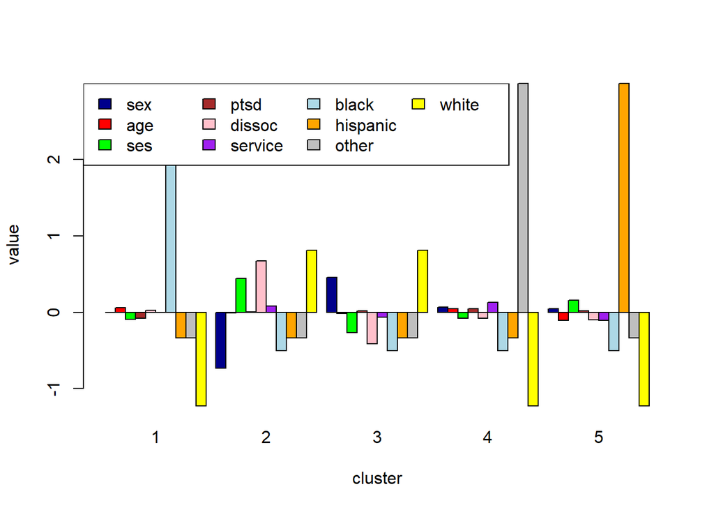

```r
myColors <- c("darkblue", "red", "green", "brown", "pink", "purple", "lightblue", "orange", "grey", "yellow")
barplot(t(trauma_clusters$centers), beside = TRUE, xlab="cluster",
ylab="value", col = myColors)
legend("topleft", ncol=4, legend = c("sex", "age", "ses", "ptsd", "dissoc", "service", "black", "hispanic", "other", "white"), fill = myColors)
```

On this barplot, the bars in each cluster represents `sex, age, ses, ptsd, dissoc, service, black, hispanic, other,` and `white`, respectively. It is quite obvious that each cluster has some unique features.

Next, we can compare the *k-means* computed cluster labels to the *original labels*. Let’s evaluate the similarities between the automated cluster labels and their real class counterparts using a confusion matrix table, where rows represent the k-means clusters, columns show the actual labels, and the cell values include the frequencies of the corresponding pairings.

```r
trauma$clusters<-trauma_clusters$cluster
table(trauma$clusters, trauma$traumatype)
```

```
##
##     dvexp neglect physabuse psychabuse sexabuse
##   1     0       0       100          0      100
##   2    13     152         0         74        0
##   3    37     198         0        126        0
##   4   100       0         0          0        0
##   5   100       0         0          0        0
```

We can see that all of the children in cluster 4 belongs to `dvexp` (exposure to domestic violence or intimate partner violence). The model groups all `physabuse` and `sexabuse` cases into *cluster1* but can;t distinguish between them. Majority (200/250) of all `dvexp` children are grouped in *clusters 4 and 5*. Finally, `neglect` and `psychabuse` types are mixed in *clusters 2 and 3*.

Let’s review the output Silhouette value summary. It works well as only a small portion of samples appear mis-clustered.

```r
dis_tra = dist(tr_z)
sil_tra = silhouette(trauma_clusters$cluster, dis_tra)
summary(sil_tra)
```

```
## Silhouette of 1000 units in 5 clusters from silhouette.default(x = trauma_clusters$cluster, dist = dis_tra) :
##  Cluster sizes and average silhouette widths:
##       200       239       361       100       100
## 0.2925595 0.1548029 0.1369327 0.3467176 0.3425344
## Individual silhouette widths:
##    Min. 1st Qu.  Median    Mean 3rd Qu.    Max.
## 0.00796 0.11269 0.20893 0.21387 0.30575 0.42344
```

```r
#plot(sil_tra)
# report the overall mean silhouette value
mean(sil_tra[,"sil_width"])
```

```
## [1] 0.2138677
```

```r
# The sil object colnames  are ("cluster", "neighbor", "sil_width")
```

Next, let’s try to tune $k$ with **k-means++** and see if $k=5$ appears to be optimal.

```r
mat = matrix(0,nrow = 11)
for (i in 2:11){
  set.seed(321)
  clust_kpp = kmeans(tr_z, kpp_init(tr_z, i), iter.max=100, algorithm='Lloyd')
  sil = silhouette(clust_kpp$cluster, dis_tra)
  mat[i] = mean(as.matrix(sil)[,3])
}
mat
```

```
##            [,1]
##  [1,] 0.0000000
##  [2,] 0.2433222
##  [3,] 0.1675486
##  [4,] 0.1997315
##  [5,] 0.2116534
##  [6,] 0.2400086
##  [7,] 0.2251367
##  [8,] 0.2199859
##  [9,] 0.2249569
## [10,] 0.2347122
## [11,] 0.2304451
```

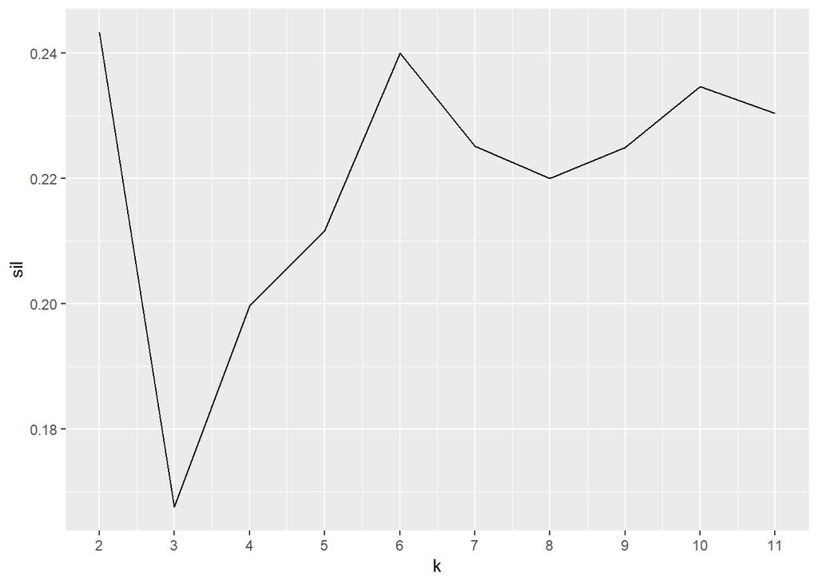

```r
ggplot(data.frame(k=2:11,sil=mat[2:11]),aes(x=k,y=sil))+geom_line()+scale_x_continuous(breaks = 2:11)
```

Finally, let’s use **k-means++** with $k=6$ and set the algorithm’s maximal iteration before rerunning the experiment:

```r
set.seed(1234)
clust_kpp = kmeans(tr_z, kpp_init(tr_z, 6), iter.max=100, algorithm='Lloyd')
sil = silhouette(clust_kpp$cluster, dis_tra)
summary(sil)
```

```
## Silhouette of 1000 units in 6 clusters from silhouette.default(x = clust_kpp$cluster, dist = dis_tra) :
##  Cluster sizes and average silhouette widths:
##       422       100       178        85        15       200
## 0.2166778 0.3353976 0.1898492 0.2478090 0.2294502 0.2836607
## Individual silhouette widths:
##    Min. 1st Qu.  Median    Mean 3rd Qu.    Max.
## 0.03672 0.19730 0.23076 0.24001 0.27714 0.40646
```

```r
# plot(sil)
# report the overall mean silhouette value
mean(sil[,"sil_width"])
```

```
## [1] 0.2400086
```

As we showed earlier, we can interpret the resulting `kmeans` clusters in the context of this pediatric trauma study, by examining `clust_kpp$centers`.

# 7 Feature selection for k-Means clustering

A very active area of research involves feature selection for unsupervised machine-learning clustering, including k-means clustering. We won’t go into details here, but we list some of the current strategies to chose salient features in situations where we don’t have ground-truth labels.

- For Gaussian model-based clustering, the [‘mclust’ package](https://cran.r-project.org/web/packages/mclust) provides the functionality to learn and report the clusters, as well as perform variable selection using [‘clustvarsel’](https://cran.r-project.org/web/packages/clustvarsel/index.html).
- a [feature selection for clustering article](http://citeseerx.ist.psu.edu/viewdoc/download?doi=10.1.1.295.8115&rep=rep1&type=pdf) provides a review of possible strategies.
- Unsupervised Feature Selection for k-means Clustering provides specifics for variable selection for the k-means algorithm.
- A [Feature Selection for Clustering](https://link.springer.com/chapter/10.1007/3-540-45571-X_13) paper presents an approach where features are ranked according to their importance on clustering and then a subset of important features are chosen.

# 8 Practice Problem: Youth Development

Use [Boys Town Study of Youth Development data](https://umich.instructure.com/courses/38100/files/folder/Case_Studies), second case study, CaseStudy02_Boystown_Data.csv, we used in [Chapter 6](http://www.socr.umich.edu/people/dinov/courses/DSPA_notes/06_LazyLearning_kNN.html), to find clusters using variables about GPA, alcohol abuse, attitudes on drinking, social status, parent closeness and delinquency for clustering(all variables other than gender and ID).

First we must load the data and transfer `sex`, `dadjob` and `momjob` into dummy variables.

```r
boystown<-read.csv("https://umich.instructure.com/files/399119/download?download_frd=1", sep=" ")
boystown$sex<-boystown$sex-1
boystown$dadjob <- (-1)*(boystown$dadjob-2)
boystown$momjob <- (-1)*(boystown$momjob-2)
str(boystown)
```

```
## 'data.frame':    200 obs. of  11 variables:
##  $ id        : int  1 2 3 4 5 6 7 8 9 10 ...
##  $ sex       : num  0 0 0 0 1 1 0 0 1 1 ...
##  $ gpa       : int  5 0 3 2 3 3 1 5 1 3 ...
##  $ Alcoholuse: int  2 4 2 2 6 3 2 6 5 2 ...
##  $ alcatt    : int  3 2 3 1 2 0 0 3 0 1 ...
##  $ dadjob    : num  1 1 1 1 1 1 1 1 1 1 ...
##  $ momjob    : num  0 0 0 0 1 0 0 0 1 1 ...
##  $ dadclose  : int  1 3 2 1 2 1 3 6 3 1 ...
##  $ momclose  : int  1 4 2 2 1 2 1 2 3 2 ...
##  $ larceny   : int  1 0 0 3 1 0 0 0 1 1 ...
##  $ vandalism : int  3 0 2 2 2 0 5 1 4 0 ...
```

Then, extract all the variables, except the first two columns (subject identifiers and genders).

```r
boystown_sub<-boystown[, -c(1, 2)]
```

Next, we need to standardize and clustering the data with `k=3`. You may have the following centers (numbers could be a little different).

```
##          gpa  Alcoholuse      alcatt     dadjob      momjob   dadclose
## 1 -0.5101243 -0.08555163 -0.30098866  0.1939577  0.04868109  1.1914502
## 2 -0.2753631  0.49998217  0.13804858 -0.2421906 -0.30151766 -0.4521484
## 3  0.6590193 -0.51256447  0.04599325  0.1451756  0.31107377 -0.2896562
##      momclose    larceny  vandalism
## 1  0.65647213 -0.1755012 -0.4453044
## 2 -0.33341358 -0.4017282  0.5252308
## 3 -0.06343891  0.5769583 -0.2981561
```

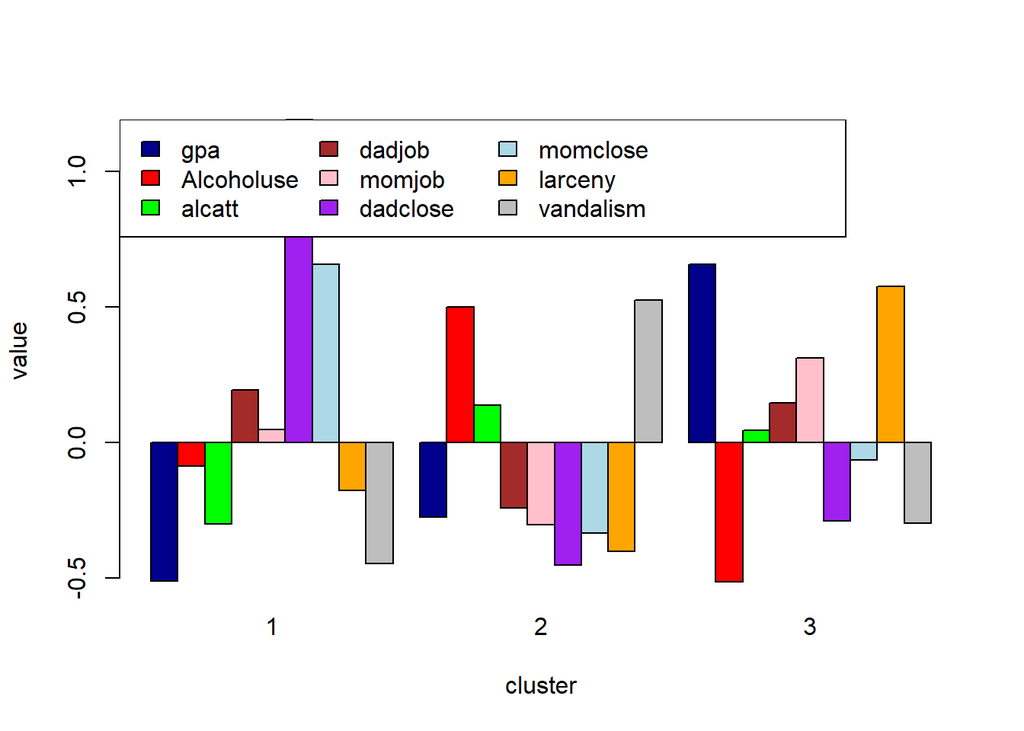

Add *k-means* cluster labels as a new (last) column back in the original dataset.

To investigate the gender distribution within different clusters we may use `aggregate()`.

```r
# Compute the averages for the variable 'sex', grouped by cluster
aggregate(data=boystown, sex~clusters, mean)
```

```
##   clusters       sex
## 1        1 0.6875000
## 2        2 0.5802469
## 3        3 0.6760563
```

Here `clusters` is the new vector indicating cluster labels. The gender distribution does not vary much between different cluster labels.

# 9 Hierarchical Clustering

Recall from [Chapter 6 (Lazy Learning)](http://www.socr.umich.edu/people/dinov/courses/DSPA_notes/06_LazyLearning_kNN.html) that there are three large classes of unsupervised clustering methods - Bayesian, partitioning-based, and hierarchical. Hierarchical clustering represents a family of techniques that build hierarchies of clusters using one of two complementary strategies:

- *Generative* methods (also known as agglomerative) represent bottom-up approaches that are initialized with each individual observation being its own cluster, and the iterative protocol aggregates observations (i.e., merges clusters) by pairing similar clusters, which results in higher hierarchy levels.
- *Discriminative* methods (also known as divisive) represent a reversed top-down techniques that are initialized by all observations belonging to a single cluster, which is recursively split into higher hierarchical levels.

In both situations, cluster splits and merges are determined by minimizing some objective function using a greedy algorithm (e.g., gradient descent). It’s common to illustrate hierarchical clustering results as dendrograms. One example of genomics data hierarchical clustering using probability distributions is available [here (DOI: 10.1016/j.jtbi.2016.07.032)](https://doi.org/10.1016/j.jtbi.2016.07.032).

Decisions about merging or splitting nodes in the hierarchy heavily depend the specific a distance metric used to measure the dissimilarity between sets of observations in the original cluster and the candidate children (sub)clusters. It’s common to employ standard metrics ($d$) for measuring distances between pairs of observations (e.g., Euclidean, Manhattan, Mahalanobis) and a linkage criterion connecting cluster-dissimilarity of sets to the paired distances of observations in the cluster sets (e.g., maximum/complete linkage clustering $\max \{ d ( a , b ) : a \in A , b \in B \}$, minimum/single linkage clustering $\min \{ d ( a , b ) : a \in A , b \in B \}$, mean linkage clustering $\frac {1}{|A|.|B|} \sum_{a\in A} {\sum _{b\in B}d(a,b)}$).

There are a number of `R` **hierarchical clustering** packages, including:

- `hclust` in base R.
- `agnes` in the `cluster` package.

Alternative distance measures (or linkages) can be used in all Hierarchical Clustering, e.g., *single*, *complete* and *ward*.

We will demonstrate hierarchical clustering using case-study 1 ([Divorce and Consequences on Young Adults](https://umich.instructure.com/files/399121/download?download_frd=1)). Pre-set $k=3$ and notice that we have to use normalized data for hierarchical clustering.

```r
library(cluster)
pitch_sing = agnes(di_z, diss=FALSE, method='single')
pitch_comp = agnes(di_z, diss=FALSE, method='complete')
pitch_ward = agnes(di_z, diss=FALSE, method='ward')
sil_sing = silhouette(cutree(pitch_sing, k=3), dis)
sil_comp = silhouette(cutree(pitch_comp, k=3), dis)
# try 10 clusters, see plot above
sil_ward = silhouette(cutree(pitch_ward, k=10), dis)
```

You can generate the hierarchical plot by `ggdendrogram` in the package `ggdendro`.

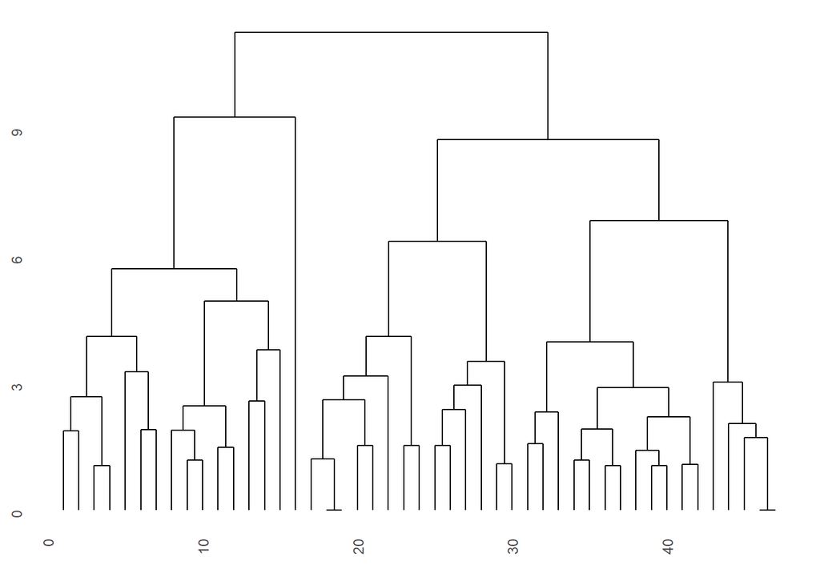

```r
# install.packages("ggdendro")
library(ggdendro)
ggdendrogram(as.dendrogram(pitch_ward), leaf_labels=FALSE, labels=FALSE)
```

```r
mean(sil_ward[,"sil_width"])
```

```
## [1] 0.2398738
```

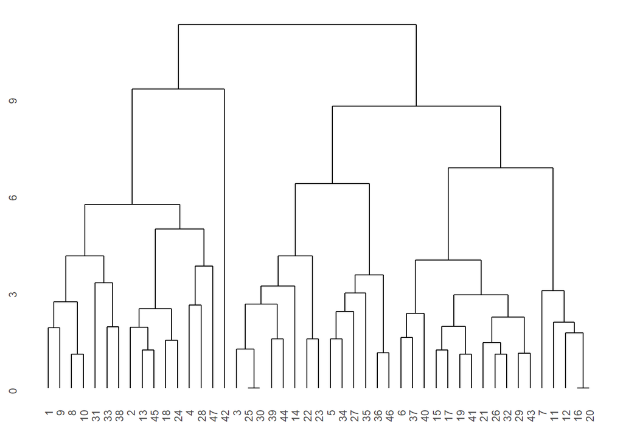

```r
ggdendrogram(as.dendrogram(pitch_ward), leaf_labels=TRUE, labels=T, size=10)
```

Generally speaking, the best result should come from **wald** linkage, but you should also try complete linkage (method=‘complete’). We can see that the hierarchical clustering result (average silhouette value $\sim 0.24$) mostly agrees with the prior *k-means* ($0.2$) and *k-means++* ($0.2$) results.

```r
summary(sil_ward)
```

```
## Silhouette of 47 units in 10 clusters from silhouette.default(x = cutree(pitch_ward, k = 10), dist = dis) :
##  Cluster sizes and average silhouette widths:
##           4           5           6           3           6          12
##  0.25905454  0.29195989  0.29305926 -0.02079056  0.19263836  0.26268274
##           5           2           3           1
##  0.32594365  0.44074717  0.08760990  0.00000000
## Individual silhouette widths:
##    Min. 1st Qu.  Median    Mean 3rd Qu.    Max.
## -0.1477  0.1231  0.2577  0.2399  0.3524  0.5176
```

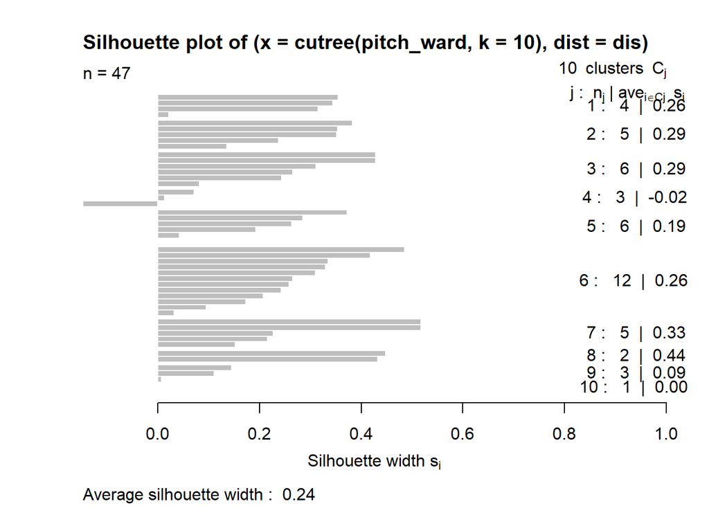

```r
plot(sil_ward)
```

# 10 Spectral Clustering

Spectral clustering relies on decomposition of the similarity-matrix in terms of its spectrum of eigenvalues. The similarity matrix of the data is computed using some pairwise distances between all observations in the dataset. This spectral decomposition is used to reduce the data dimensionality prior to clustering. Typically, one precomputes the distance matrix first and feeds it as an input to the clustering method.

For a dataset of records, the similarity matrix is a symmetric matrix $A=\{a_{ij}\geq 0\}_{ij}$ encoding the similarity measures between pairs of data points indexed by $1\leq i,j \leq n$. Most spectral clustering methods employ a traditional *cluster method* like $k$-means clustering applied on the eigenvectors of the *Laplacian* similarity matrix. There are alternative approaches to define a Laplacian that lead to different mathematical interpretations of the spectral clustering protocol. The *relevant eigenvectors* correspond to the few *smallest eigenvalues* of the Laplacian. The exception is that the smallest eigenvalue, which will have a value of $0$. This process (finding the smallest eigenvalues) is analogous to computing the *largest* few eigenvalues of an operator representing a *function* of the original Laplacian.

The underlying philosophy of spectral clustering has roots in physics, e.g., partitioning of a mass-spring system. The analytical concept corresponding to physical mass is data point and mass-characteristics (e.g., stiffness parameter) relates to weights of edges describing pairwise similarity of related data points. The eigenvalue problem in spectral clustering analytics maps to physical transversal vibration modes of mass-spring systems. Mathematically, the eigenvalue problem for the Laplacian matrix is $L=D-A$, where $D=\{ d_{i,i} = \sum_j a_{i,j};\ d_{i\not= j}=0 \}$ is a diagonal matrix.

Tightly coupled spring masses in the physical system jointly move in space from the equilibrium state in low-frequency vibration modes. Eigenvector components that correspond to the smallest eigenvalues of the Laplacian can be used to derive clustering of the masses (data points).

For instance, the *normalized cuts* spectral clustering algorithm partitions points in $B$ into two sets $B_1$ and $B_2$ based on the eigenvector $v$ corresponding to the *second-smallest* Laplacian eigenvalue, where the *symmetrized-and-normalized* Laplacian matrix is defined by:

$$L^\text{norm} = I-\left (D^{-1/2} A D^{-1/2}\right ).$$

Similarly, we can take the eigenvector corresponding to the *largest eigenvalue* of the adjacency matrix

$$P = D^{-1}A.$$

The key is to obtain the spectrum of the Laplacian. Then using the eigenvectors, we can cluster the observations in many alternative ways. For instance, the cases can be partitioned by computing the median $m$ of the components of the *second smallest eigenvector* $v$ and mapping all points whose component in $v$ is greater than $m$ in $B_1$ and the remaining cases in its complement, $B_2$. Repeated partitioning of the data into the subsets using this protocol will induce a classification scheme (spectral clustering) of the data.

The unnormalized spectral clustering pseudo algorithm is listed below.

*Input*: *Similarity matrix*, $A\in R^n\times R^n$, $k=$ number of clusters Construct a *similarity graph* modeling the local neighborhood relationships, where the similarity function encodes mainly local neighborhoods. For instance, a Gaussian similarity function $a(x_i,x_j)=\exp{\left (-\frac{||x_i-x_j||^2}{2\sigma^2}\right )}$, where $\sigma$ controls the width of the neighborhoods. Let $W$ be its *weighted adjacency matrix*, corresponding to the similarity graph, $W= (w_{i,j})_{i,j}$, where $w_{i,j}=w_{j,i}$ and $w_{i,j}= 0$ implies that the vertices $x_i$ and $x_j$ are not connected. Compute the unnormalized Laplacian $L$. Compute the first $k$ eigenvectors of $L$ and let $V\in R^{n\times k}$ be the matrix containing these $k$ vectors as columns. For $1\leq i\leq n$, let $y_i\in R^k$ be the vector corresponding to the $i^{th}$ row of $V$. Cluster the points $\{y_i \}_{1\leq i\leq n}$ in $k$-clusters, $\{C_i\}_{i=1}^k$ in $R^k$ using $k$-means clustering. *Output*: Clusters $\{A_i\}_{i=1}^k$, where $A_i=\{j | y_i \in C_i\}$.

Let’s look at one specific implementation of spectral clustering for segmenting/classifying a region of interest (ROI) representing [brain hematoma](https://en.wikipedia.org/wiki/Subdural_hematoma) in a 2D MRI image ([MRI_ImageHematoma.jpg](https://umich.instructure.com/files/1627149/download?download_frd=1)).

```r
# Import the Brain 2D image MRI_ImageHematoma.jpg
library(jpeg)
img_url <- "https://umich.instructure.com/files/1627149/download?download_frd=1"
img_file <- tempfile(); download.file(img_url, img_file, mode="wb")
img <- readJPEG(img_file)

# To expedite the calculaitons, reduce the size of 2D image
library("EBImage")
img <- img[ , , 1] # take the first RGB-color channel
# width and height of the original image
dim(img)[1:2]
```

```
## [1] 256 256
```

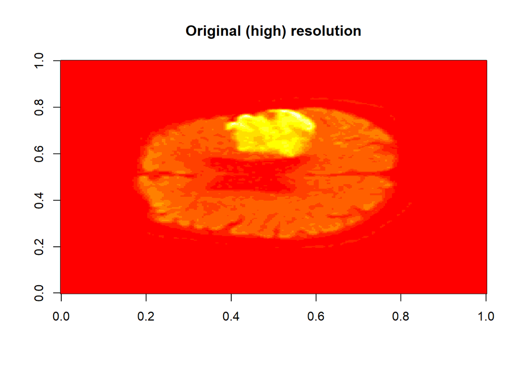

```r
olddim <- c(dim(img)[1], dim(img)[2])
newdim <- c(64, 64)  # new smaller image dimensions
img1 <- resize(img, w = newdim[1], h = newdim[2])
image(img, main="Original (high) resolution")
```

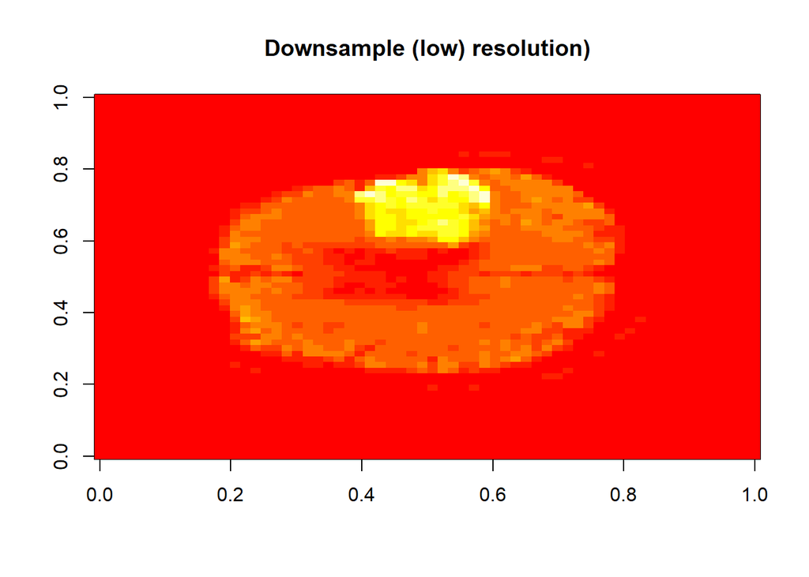

```r
image(img1, main="Downsample (low) resolution)")
```

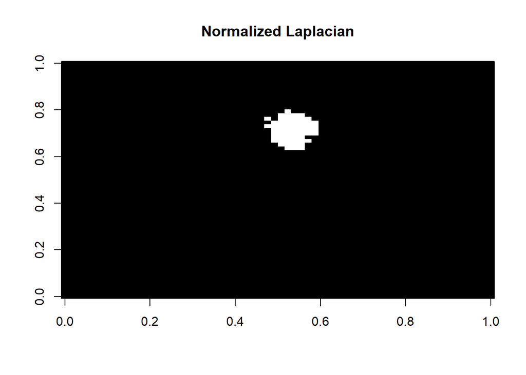

```r
# Convert image matrix to long vector (i,j, value)
imgvec <- matrix(NA, prod(dim(img1)),3)
counter <- 1
for (r in 1:nrow(img1)) {
  for (c in 1:ncol(img1)) {
    imgvec[counter,1] <- r
    imgvec[counter,2] <- c
    imgvec[counter,3] <- img1[r,c]
    counter <- counter+1
  }
}

# Compute the Similarity Matrix A
pixdiff <- 2
sigma2 <- 0.01
simmatrix <- matrix(0, counter-1, counter-1)

for(r in 1:nrow(imgvec)) {
  # Verbose
  # cat(r, "out of", nrow(imgvec), "\n")
  simmatrix[r,] <- ifelse(abs(imgvec[r,1]-imgvec[,1])<=pixdiff & abs(imgvec[r,2]-imgvec[,2])<=pixdiff,exp(-(imgvec[r,3]-imgvec[,3])^2/sigma2),0)
}

# Compute the graph Laplacians
# U: unnormalized graph Laplacian (U=D-A)
# L: normalized graph Laplacian, which can be caomputed in different ways:
## L1:   Simple Laplacian: I - D^{-1} A, which can be seen as a random walk, where D^{-1} A is the transition matrix, which yields spectral clustering with groups of nodes such that the random walk seldom transitions from one group to another.
## L2:   Normalized Laplacian D^{-1/2} A D^{-1/2}, or
## L3:   Generalized Laplacian: D^{-1} A.

D <- diag(rowSums(simmatrix))
Dinv <- diag(1/rowSums(simmatrix))
L <- diag(rep(1,nrow(simmatrix)))-Dinv %*% simmatrix
U <- D-simmatrix

# Compute the eigen-spectra for the nrmalized and unnormalized Laplacians
evL <- eigen(L, symmetric=TRUE)
evU <- eigen(U, symmetric=TRUE)

# Apply k-means clustering on the eigenspectra of both Laplacians
kmL <- kmeans(evL$vectors[,(ncol(simmatrix)-1):(ncol(simmatrix)-0)],
              centers=2,nstart=5)
segmatL <- matrix(kmL$cluster-1, newdim[1], newdim[2], byrow=T)

kmU <- kmeans(evU$vectors[,(ncol(simmatrix)-1):(ncol(simmatrix)-0)],
              centers=2,nstart=5)
segmatU <- matrix(kmU$cluster-1, newdim[1], newdim[2], byrow=T)

# Plot the pair of spectral clusters (hematoma and normal brain areas)
image(segmatL, col=grey((0:15)/15), main="Normalized Laplacian")
```

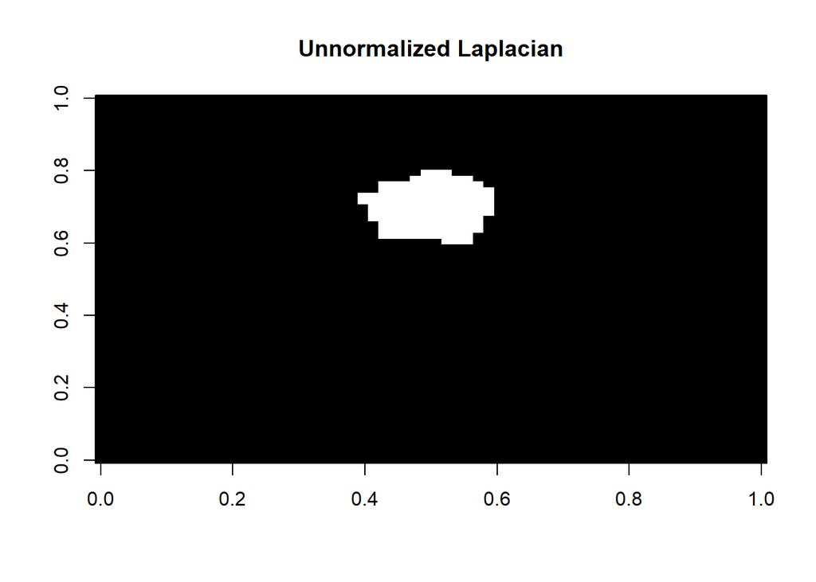

```r
image(segmatU, col=grey((0:15)/15), main="Unnormalized Laplacian")
```

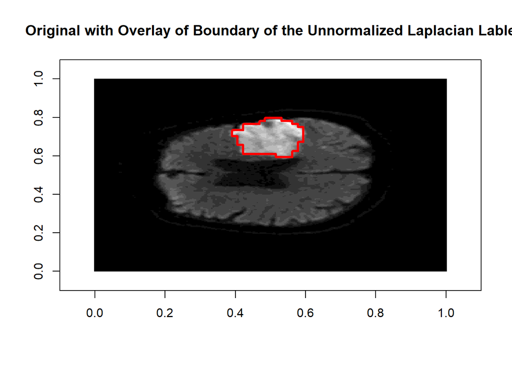

```r
# Overlay the outline of the ROI-segmentaiton region on top of original image
image(seq(0, 1, length.out=olddim[1]), seq(0, 1, length.out=olddim[2]),
      img, col = grey((0:15)/15), xlim=c(-0.1, 1.1),
      ylim=c(-0.1, 1.1), xlab="",ylab="", main="Original with Overlay of Boundary of the Unnormalized Laplacian Lable")

# Compute the outline of the spectral segmentation and plot it as piecewise polygon - line segments
segmat <- segmatU
linecol <- 2
linew <- 3
for(r in 2:newdim[1]) {
  for (c in 2:newdim[2]) {
    if(abs(segmat[r-1,c]-segmat[r,c])>0) {
      xloc <- (r-1)/(newdim[1])
      ymin <- (c-1)/(newdim[2])
      ymax <- (c-0)/(newdim[2])
      segments(xloc, ymin, xloc, ymax, col=linecol,lwd=linew)
    }
    if(abs(segmat[r,c-1]-segmat[r,c])>0) {
      yloc <- (c-1)/(newdim[2])
      xmin <- (r-1)/(newdim[1])
      xmax <- (r-0)/(newdim[1])
      segments(xmin, yloc, xmax, yloc, col=linecol,lwd=linew)
    }
  }
}
```

Let’s try spectral clustering on the [Knee Pain Dataset](http://wiki.socr.umich.edu/index.php/SOCR_Data_KneePainData_041409) using the `kernlab::specc()` method.

```r
#Get the data first
library("XML"); library("xml2"); library("rvest")

wiki_url <- read_html("http://wiki.socr.umich.edu/index.php/SOCR_Data_KneePainData_041409")
html_nodes(wiki_url, "#content")
```

```
## {xml_nodeset (1)}
## [1] <div id="content" class="mw-body-primary" role="main">\n\t<a id="top ...
```

```r
kneeRawData <- html_table(html_nodes(wiki_url, "table")[[2]])
normalize<-function(x){
  return((x-min(x))/(max(x)-min(x)))
}
kneeRawData_df <- as.data.frame(cbind(normalize(kneeRawData$x), normalize(kneeRawData$Y), as.factor(kneeRawData$View)))
colnames(kneeRawData_df) <- c("X", "Y", "Label")

# randomize the rows of the DF as RF, RB, LF and LB labels of classes
# which are by default sequentially ordered
set.seed(1234)
kneeRawData_df <- kneeRawData_df[sample(nrow(kneeRawData_df)), ]
# summary(kneeRawData_df)
# View(kneeRawData_df)

# Artificially reduce the size of hte data from 8K to 1K to get results faster
kneeDF <- data.frame(x=kneeRawData_df[1:1000, 1],
                     y=kneeRawData_df[1:1000, 2],
                     class=as.factor(kneeRawData_df[1:1000, 3]))
head(kneeDF)
```

```
##           x         y class
## 1 0.1188590 0.5057803     4
## 2 0.3248811 0.6040462     2
## 3 0.3153724 0.4971098     2
## 4 0.3248811 0.4161850     2
## 5 0.6941363 0.5289017     1
## 6 0.3217116 0.4595376     2
```

```r
# Do the spectral clustering
library(kernlab)
knee_data <- cbind(kneeDF$x, kneeDF$y); dim(knee_data)
```

```
## [1] 1000    2
```

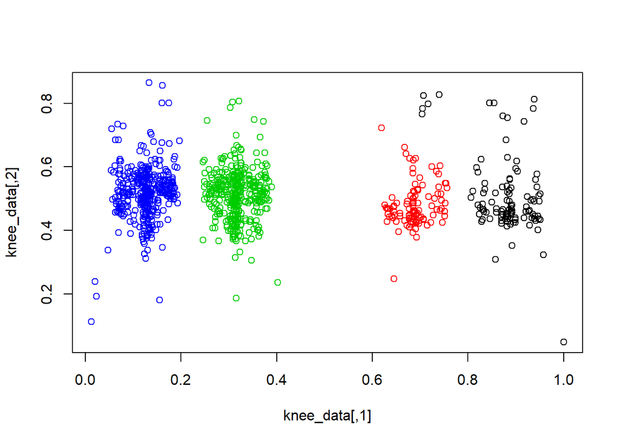

```r
spectral_knee <- specc(knee_data, iterations=10, centers=4)
plot(knee_data, col=spectral_knee, pch=1)    # estimated clusters
```

```r
# points(knee_data, col=kneeDF$class, pch=0)
```

# 11 Gaussian mixture models

More [details about Gaussian mixture models (GMM) are provided here](http://escholarship.org/uc/item/1rb70972). Also see the [SOCR Gaussian Mixture Model (Java) interactive activity](http://wiki.stat.ucla.edu/socr/index.php/SOCR_EduMaterials_Activities_2D_PointSegmentation_EM_Mixture). Below is a brief introduction to GMM using the `Mclust` function in the *R* package `mclust`.

For multivariate mixture, there are totally 14 possible models:

- “EII” = spherical, equal volume
- “VII” = spherical, unequal volume
- “EEI” = diagonal, equal volume and shape
- “VEI” = diagonal, varying volume, equal shape
- “EVI” = diagonal, equal volume, varying shape
- “VVI” = diagonal, varying volume and shape
- “EEE” = ellipsoidal, equal volume, shape, and orientation
- “EVE” = ellipsoidal, equal volume and orientation (*)
- “VEE” = ellipsoidal, equal shape and orientation (*)
- “VVE” = ellipsoidal, equal orientation (*)
- “EEV” = ellipsoidal, equal volume and equal shape
- “VEV” = ellipsoidal, equal shape
- “EVV” = ellipsoidal, equal volume (*)
- “VVV” = ellipsoidal, varying volume, shape, and orientation

For more practical details, you may refer to [`Mclust`](https://cran.r-project.org/web/packages/mclust/mclust.pdf) and its [vignettes](https://cran.r-project.org/web/packages/mclust/vignettes/mclust.html). Additional theoretical details are available in [C. Fraley and A. E. Raftery (2002). Model-based clustering, discriminant analysis, and density estimation. Journal of the American Statistical Association 97:611:631](http://dx.doi.org/10.1198/016214502760047131).

Let’s use the [Divorce and Consequences on Young Adults dataset](https://umich.instructure.com/files/399121/download?download_frd=1) for a demonstration.

```r
library(mclust)
set.seed(1234)
gmm_clust <- Mclust(di_z)
summary(gmm_clust, parameters = TRUE)
```

```
## ----------------------------------------------------
## Gaussian finite mixture model fitted by EM algorithm
## ----------------------------------------------------
##
## Mclust VEI (diagonal, equal shape) model with 3 components:
##
##  log-likelihood  n df       BIC       ICL
##       -366.2421 47 32 -855.6889 -855.6889
##
## Clustering table:
##  1  2  3
## 16 11 20
##
## Mixing probabilities:
##         1         2         3
## 0.3404255 0.2340426 0.4255319
##
## Means:
##                    [,1]       [,2]         [,3]
## DIVYEAR     -1.31232783  0.6773305  0.677330492
## momint      -0.12774695  0.3940885 -0.114551109
## dadint       0.20799207 -0.6091287  0.168627126
## momclose    -0.06879301  0.1182558 -0.010006256
## depression   0.16395724 -0.2363539 -0.001171123
## livewithmom -0.05830267  1.3770536 -0.710737338
## gethitched   0.17425492 -0.1308860 -0.067416656
##
## Variances:
## [,,1]
##                DIVYEAR  momint   dadint momclose depression livewithmom
## DIVYEAR     0.08984375  0.0000  0.00000  0.00000    0.00000   0.0000000
## momint      0.00000000 15.9914  0.00000  0.00000    0.00000   0.0000000
## dadint      0.00000000  0.0000 14.23757  0.00000    0.00000   0.0000000
## momclose    0.00000000  0.0000  0.00000 19.30599    0.00000   0.0000000
## depression  0.00000000  0.0000  0.00000  0.00000   12.66066   0.0000000
## livewithmom 0.00000000  0.0000  0.00000  0.00000    0.00000   0.3188004
## gethitched  0.00000000  0.0000  0.00000  0.00000    0.00000   0.0000000
##             gethitched
## DIVYEAR       0.000000
## momint        0.000000
```

[output cut: 24 more lines]

```
## DIVYEAR     0.003765412 0.0000000 0.0000000 0.000000  0.0000000
## momint      0.000000000 0.6702105 0.0000000 0.000000  0.0000000
## dadint      0.000000000 0.0000000 0.5967061 0.000000  0.0000000
## momclose    0.000000000 0.0000000 0.0000000 0.809127  0.0000000
## depression  0.000000000 0.0000000 0.0000000 0.000000  0.5306166
## livewithmom 0.000000000 0.0000000 0.0000000 0.000000  0.0000000
## gethitched  0.000000000 0.0000000 0.0000000 0.000000  0.0000000
##             livewithmom gethitched
## DIVYEAR      0.00000000  0.0000000
## momint       0.00000000  0.0000000
## dadint       0.00000000  0.0000000
## momclose     0.00000000  0.0000000
## depression   0.00000000  0.0000000
## livewithmom  0.01336114  0.0000000
## gethitched   0.00000000  0.1252645
```

```r
gmm_clust$modelName
```

```
## [1] "VEI"
```

Thus, the optimal model, `VEI`, has 3 components.

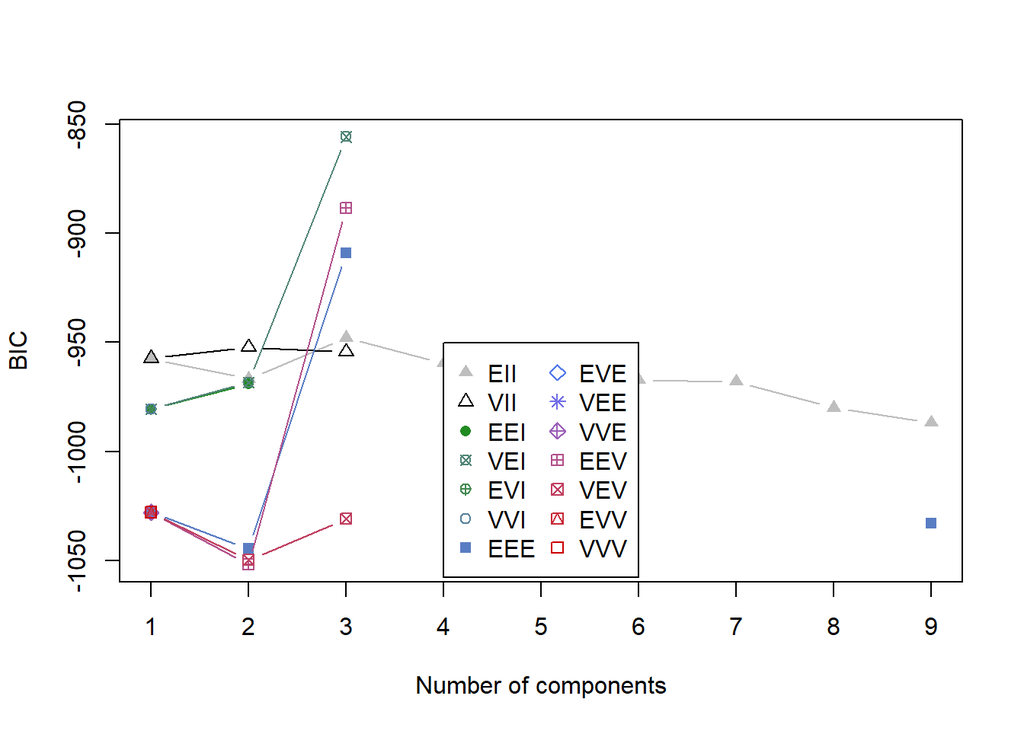

```r
plot(gmm_clust$BIC, legendArgs = list(x = "bottom", ncol = 2, cex = 1))
```

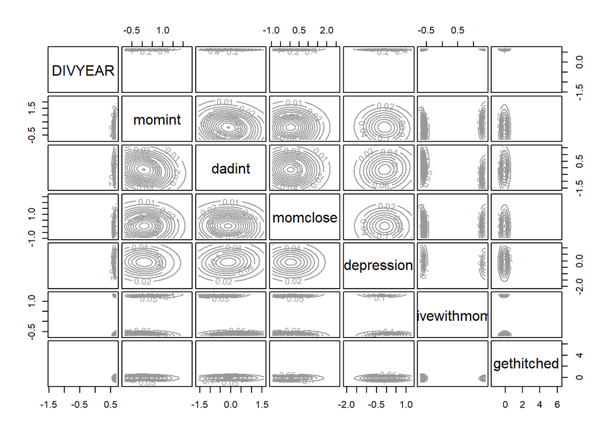

```r
plot(gmm_clust, what = "density")
```

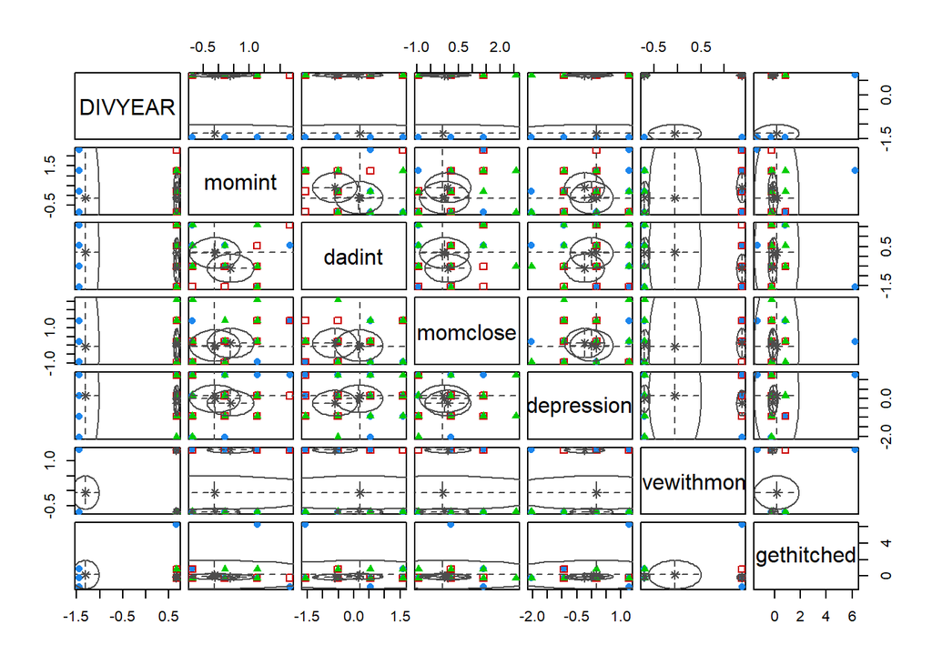

```r
plot(gmm_clust, what = "classification")
```

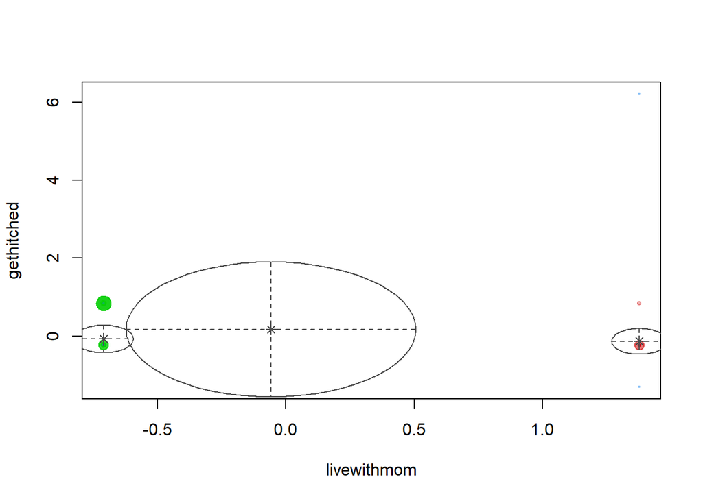

```r
plot(gmm_clust, what = "uncertainty", dimens = c(6,7), main = "livewithmom vs. gethitched")
```

```r
# Mclust Dimention Reduction clustering
gmm_clustDR <- MclustDR(gmm_clust, lambda=1)
summary(gmm_clustDR)
```

```
## -----------------------------------------------------------------
## Dimension reduction for model-based clustering and classification
## -----------------------------------------------------------------
##
## Mixture model type: Mclust (VEI, 3)
##
## Clusters  n
##        1 16
##        2 11
##        3 20
##
## Estimated basis vectors:
##                  Dir1      Dir2
## DIVYEAR     -0.963455  0.033455
## momint       0.018017 -0.024376
## dadint      -0.020111  0.094546
## momclose    -0.018771  0.107977
## depression   0.017151  0.089764
## livewithmom  0.069653 -0.971657
## gethitched   0.255983  0.159729
##
##                Dir1    Dir2
## Eigenvalues  1.9604   1.007
## Cum. %      66.0653 100.000
```

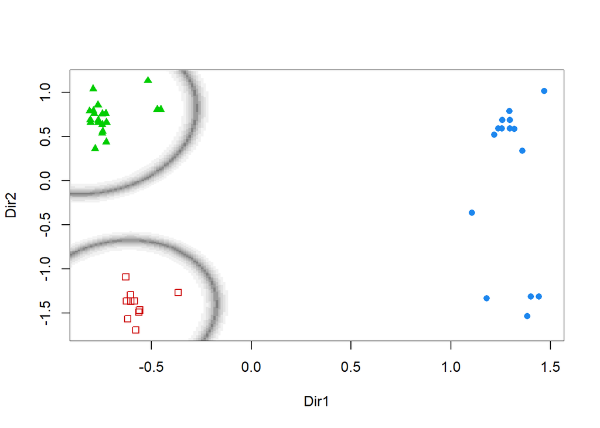

```r
plot(gmm_clustDR, what = "boundaries", ngrid = 200)
```

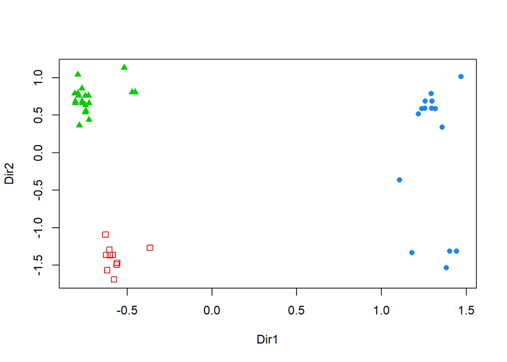

```r
plot(gmm_clustDR, what = "pairs")
plot(gmm_clustDR, what = "scatterplot")
```

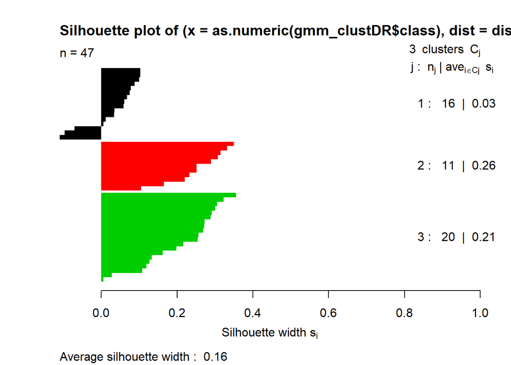

```r
# Plot the Silhouette plot to assess the quality of
# the clustering based on the Mixture of 3 Gaussians
silGauss = silhouette(as.numeric(gmm_clustDR$class), dis)
plot(silGauss, col=1:length(gmm_clustDR$class2mixcomp), border=NA)
```

To assess the model, we can print the confusion matrix comparing, say, the `Mclust` clustering labels and `divorce$depression` categories:

```r
table(divorce$depression, gmm_clust$classification)
```

```
##
##     1 2 3
##   1 2 0 1
##   2 3 5 6
##   3 4 5 8
##   4 7 1 5
```

# 12 Summary

- K-means clustering may be most appropriate for exploratory data analytics. It is highly flexible and fairly efficient in terms of tessellating data into groups.
- It can be used for data that has no *Apriori* classes (labels).
- Generated clusters may lead to phenotype stratification and/or be compared against known clinical traits.

Try to replicate these results with [other data from the list of our Case-Studies](https://umich.instructure.com/courses/38100/files/).